# Proyecto1_Trading_Ricardo_Hugo

## Proyecto 1

### MICROESTRUCTURA Y SISTEMAS DE TRADING

Profesor: Luis Gomez

Elaboración:

- Velarde, Hugo
- Ibarra, Ricardo.

Fecha: 13 de febrero 2025

## Introduction

The bid-ask spread is a fundamental concept in financial markets, representing the difference between the *highest price a buyer is willing to pay (bid)* and the *lowest price a seller is willing to accept (ask). This spread is crucial in market-making and liquidity provision, and its optimization helps in **maximizing dealer profits while minimizing losses to informed traders*.

In this analysis, we use the *Copeland & Galai model* to find the *optimal bid-ask spread*, incorporating:

- *Liquidity traders* who trade for non-informational reasons.
- *Informed traders* who possess superior knowledge about future price movements.
- *Weibull distribution* to model asset price behavior.

Using mathematical modeling and numerical optimization, we determine the spread that balances *profit from liquidity traders* and *losses to informed traders*.

## Methodology

### *Weibull Distribution for Price Modeling*

We assume that asset prices follow a *Weibull distribution*, defined as:

$$ f(S) = \frac{k}{\lambda} \left(\frac{S}{\lambda}\right)^{k-1} e^{-(S/\lambda)^k} $$

where:

- ( \lambda ) (scale parameter) controls the *price level*.
- ( k ) (shape parameter) controls *price variation*.

### *Liquidity vs. Informed Traders*

- *Liquidity traders* transact *randomly, providing **profit* to the dealer.
- *Informed traders* trade *strategically, causing **losses*.

The dealer maximizes profit by choosing an *optimal bid-ask spread* , ensuring *expected profit remains non-negative*.

### bid_ask.py module

This defines key functions for optimizing the bid-ask spread. It includes the *Weibull distribution* for modeling price behavior, functions for computing **liquidity and informed trader probabilities**, and a **utility function** that calculates dealer profit by balancing **expected revenue from liquidity traders** and **expected losses to informed traders** using numerical integration.

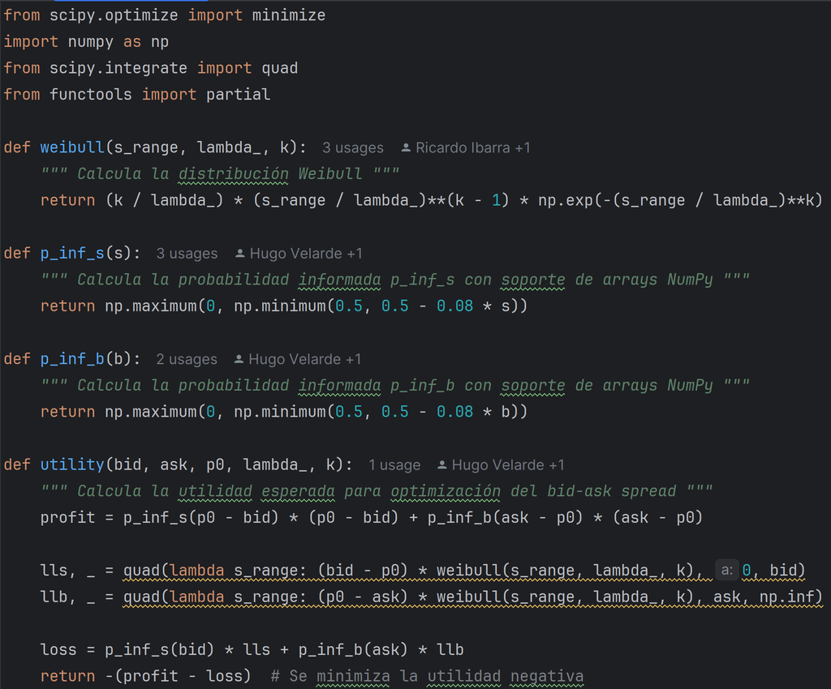

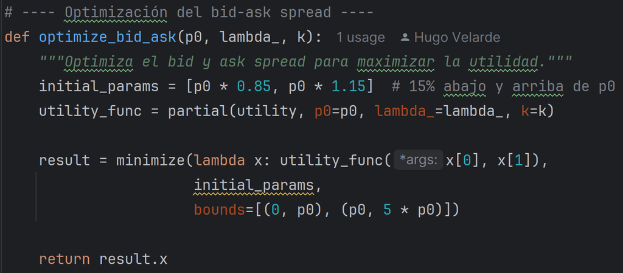

### main.py

This script runs the **full analysis and visualization** of the bid-ask spread optimization. It imports functions from `bid_ask.py`, sets **market parameters**, and performs **numerical optimization** to find the **optimal bid-ask spread** using `scipy.optimize.minimize()`. The results include:

- **Optimal bid and ask prices** based on dealer profit maximization.
- **Visualization of the Weibull distribution** for asset prices.
- **Expected revenue and cost analysis** to determine profitability.
- **Plotting the bid-ask spread and expected values** for liquidity and informed traders.

This script provides a **complete market simulation**, helping analyze how bid-ask spreads adjust in different trading environments.

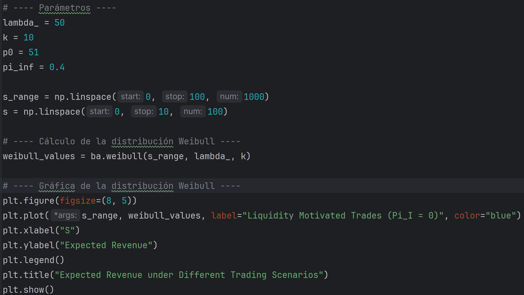

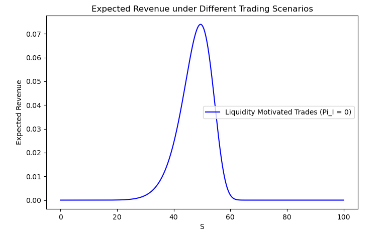

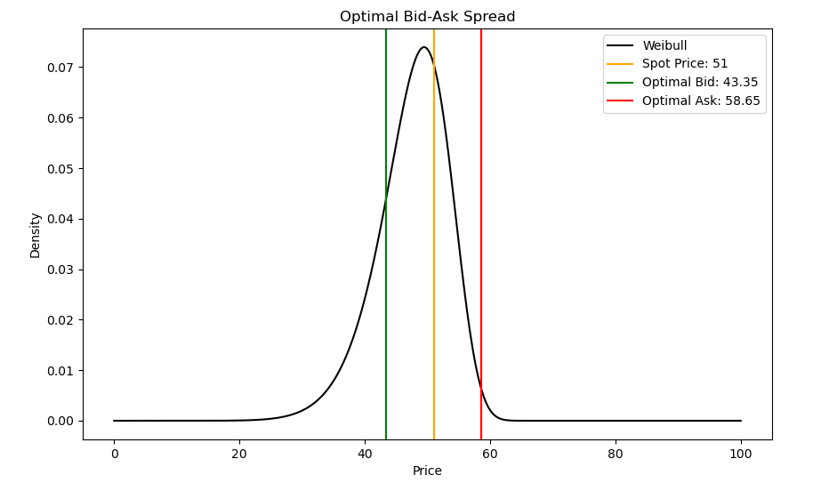

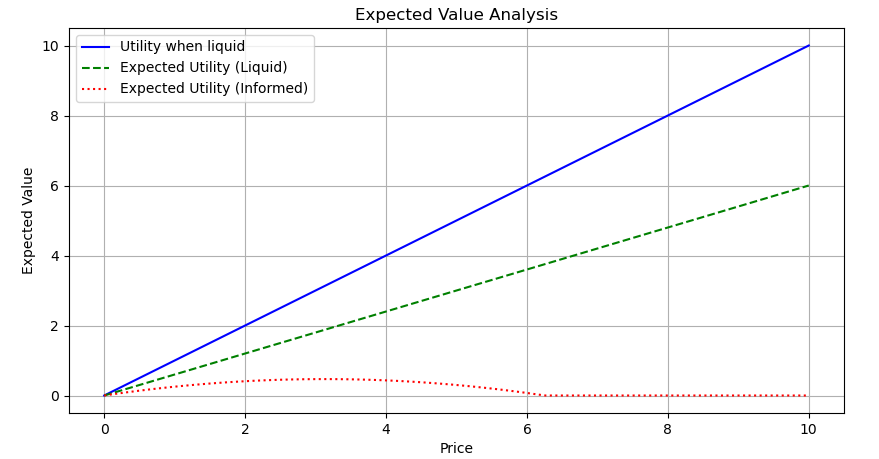